# End of Chapter 1 exercises (Page 39)

*Solution*

```r
train_uemp=jtrain2 %>% select(unem78,train) %>% group_by(train) %>% filter(train=='1' & unem78=='1')
tu=nrow(train_uemp)
tu
```

```
## [1] 45
```

```r
tot_train=nrow(jtrain2 %>% select(unem78,train) %>% group_by(train) %>% filter(train=='1'))
tot_train
```

```
## [1] 185
```

```r
round((tu/tot_train)*100,2) #Percentage Unemployed with Training
```

```
## [1] 24.32
```

```r
untrain_unemp=jtrain2 %>% select(unem78,train) %>% group_by(train) %>% filter(train=='0' & unem78=='1')
utue=nrow(untrain_unemp)
utue
```

```
## [1] 92
```

```r
tot_untrain=nrow(jtrain2 %>% select(unem78,train) %>% group_by(train) %>% filter(train=='0'))

round((utue/tot_untrain)*100,2) #Percentage Unemployed without Training
```

```
## [1] 35.38
```

```r
#Unemployment figure among untrained individuals is much larger than trained
```

**(iv) From parts (ii) and (iii), does it appear that the job training program was effective? What would make our conclusions more convincing?**

*Solution* The differences in earnings and unemployment rates suggest the training program had strong, positive effects. Our conclusions about economic significance would be stronger if we could also establish statistical significance

*End of C4*

**C5 The data in FERTIL2 were collected on women living in the Republic of Botswana in 1988. The variable children refers to the number of living children. The variable electric is a binary indicator equal to one if the woman’s home has electricity, and zero if not.**

```r
head(fertil2)
```

```
##   mnthborn yearborn age electric radio tv bicycle educ ceb agefbrth children
## 1        5       64  24        1     1  1       1   12   0       NA        0
## 2        1       56  32        1     1  1       1   13   3       25        3
## 3        7       58  30        1     0  0       0    5   1       27        1
## 4       11       45  42        1     0  1       0    4   3       17        2
## 5        5       45  43        1     1  1       1   11   2       24        2
## 6        8       52  36        1     0  0       0    7   1       26        1
##   knowmeth usemeth monthfm yearfm agefm idlnchld heduc agesq urban urb_educ
## 1        1       0      NA     NA    NA        2    NA   576     1       12
## 2        1       1      11     80    24        3    12  1024     1       13
## 3        1       0       6     83    24        5     7   900     1        5
## 4        1       0       1     61    15        3    11  1764     1        4
## 5        1       1       3     66    20        2    14  1849     1       11
## 6        1       1      11     76    24        4     9  1296     1        7
##   spirit protest catholic frsthalf educ0 evermarr
## 1      0       0        0        1     0        0
## 2      0       0        0        1     0        1
## 3      1       0        0        0     0        1
## 4      0       0        0        0     0        1
## 5      0       1        0        1     0        1
## 6      0       0        0        0     0        1
```

```r
?fertil2
```

**(i) Find the smallest and largest values of children in the sample. What is the average of children?**

*Solution*

```r
summary(fertil2$children)
```

```
##    Min. 1st Qu.  Median    Mean 3rd Qu.    Max.
##   0.000   0.000   2.000   2.268   4.000  13.000
```

**(ii) What percentage of women have electricity in the home?**

*Solution*

```r
library(dplyr)
tot_women=nrow(fertil2)
tot_women
```

```
## [1] 4361
```

```r
elec_women=nrow(fertil2 %>% filter(electric=="1"))
elec_women
```

```
## [1] 611
```

```r
perc_with_elect=round((elec_women/tot_women)*100,2)
perc_with_elect
```

```
## [1] 14.01
```

**(iii) Compute the average of children for those without electricity and do the same for those with electricity. Comment on what you find.**

*Solution*

```r
library(dplyr)
elect_child=fertil2 %>% select(children,electric) %>% filter(electric==1)

avg_chil_with_elec=mean(elect_child$children)

avg_chil_with_elec #Average Children in Electricy households
```

```
## [1] 1.898527
```

```r
non_elect_child=fertil2 %>% select(children,electric) %>% filter(electric==0)

avg_chil_with_no_elec=mean(non_elect_child$children)

avg_chil_with_no_elec #Average Children in Non Electricy households
```

```
## [1] 2.327729
```

```r
#Clearly the electricity households have fewer children
```

4. From part (iii), can you infer that having electricity “causes” women to have fewer children? Explain.

*Solution* Not directly byt may be influency of electricity devices like TV and radio are more likely to promote fewer children and more liberal thoughts.

**C6 Use the data in COUNTYMURDERS to answer this question. Use only the year 1996. The variable murders is the number of murders reported in the county. The variable execs is the number of executions that took place of people sentenced to death in the given county. Most states in the United States have the death penalty, but several do not.**

```r
head(countymurders)
```

```
##   arrests countyid density popul perc1019 perc2029 percblack percmale
## 1       2     1001   54.05 32216    20.63    15.28     22.33    40.25
## 2       3     1001   53.66 31984    20.19    15.55     22.07    40.36
## 3       2     1001   53.75 32036    19.66    15.73     21.80    40.42
## 4       7     1001   53.78 32056    19.10    15.88     21.53    40.47
## 5       3     1001   53.91 32128    18.54    15.92     21.26    40.51
## 6       1     1001   54.11 32248    18.06    15.87     20.96    40.45
##   rpcincmaint rpcpersinc rpcunemins year murders  murdrate arrestrate statefips
## 1      167.67    8780.80      29.16 1980       2 0.6208096  0.6208095         1
## 2      167.99    8232.80      43.92 1981       1 0.3126563  0.9379690         1
## 3      166.63    8327.61      71.41 1982       3 0.9364465  0.6242977         1
## 4      176.53    8545.55      72.22 1983       7 2.1836790  2.1836790         1
## 5      166.25    8965.16      40.36 1984       2 0.6225100  0.9337650         1
## 6      153.12    9254.02      44.54 1985       2 0.6201935  0.3100968         1
##   countyfips execs   lpopul execrate
## 1          1     0 10.38022        0
## 2          1     0 10.37299        0
## 3          1     0 10.37462        0
## 4          1     0 10.37524        0
## 5          1     0 10.37748        0
## 6          1     0 10.38121        0
```

```r
?countymurders
#This is a Panel dataset
```

**(i) How many counties are there in the data set? Of these, how many have zero murders? What percentage of counties have zero executions? (Remember, use only the 1996 data.)**

*Solution*

```r
library(dplyr)
county96=countymurders %>% select(countyid,year,murdrate,execs) %>% filter(year=="1996")
nrow(county96)
```

```
## [1] 2197
```

```r
county96_0murd=countymurders %>% select(countyid,year,murdrate,execs) %>% filter(year=="1996" & murdrate=="0")
nrow(county96_0murd) #Counties with Zero murders
```

```
## [1] 1051
```

```r
county96_0exec=countymurders %>% select(countyid,year,murdrate,execs) %>% filter(year=="1996" & execs=="0")
nrow(county96_0exec) #Counties with Zero executions
```

```
## [1] 2166
```

```r
perc_county_0exe=round(nrow(county96_0exec)/nrow(county96),2)*100
perc_county_0exe #Percentage of Counties with zero exexutions
```

```
## [1] 99
```

**(ii) What is the largest number of murders? What is the largest number of executions? Why is the average number of executions so small?**

*Solution*

```r
library(dplyr)
county96 %>% filter(murdrate==max(county96$murdrate))
```

```
##   countyid year murdrate execs
## 1    48033 1996 12.39157     0
```

```r
max(county96$murdrate) #Maximum Murder rate
```

```
## [1] 12.39157
```

```r
max(county96$execs) #Maximum Executions
```

```
## [1] 3
```

```r
mean(county96$execs) #The mean of execution is so small because many counties do not practice death penalty and many have no executions
```

```
## [1] 0.01593081
```

**(iii) Compute the correlation coefficient between murders and execs and describe what you find.**

*Solution*

```r
cor(county96$murdrate,county96$execs)
```

```
## [1] 0.08567281
```

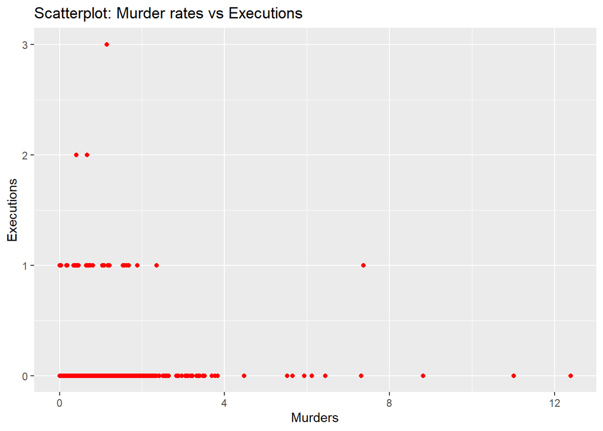

```r
library(ggplot2)
ggplot(data=county96,aes(x=murdrate,y=execs))+geom_point(col='red')+ggtitle("Scatterplot: Murder rates vs Executions")+xlab("Murders")+ylab("Executions")
```

**(iv) You should have computed a positive correlation in part (iii). Do you think that more executions cause more murders to occur? What might explain the positive correlation?**

*Solution* It is a very weak positive correlation. We would expect the two to have negative relationship. Here the data is influenced by the fact that many states have outlawed death penalty

*End of C6*

**C7 The data set in ALCOHOL contains information on a sample of men in the United States. Two key variables are self-reported employment status and alcohol abuse (along with many other variables). The variables employ and abuse are both binary, or indicator, variables: they take on only the values zero and one.**

```r
head(alcohol)
```

```
##   abuse status unemrate age educ married famsize white exhealth vghealth
## 1     1      1      4.0  50    4       1       1     1        0        0
## 2     0      3      4.0  37   12       1       5     1        0        0
## 3     0      3      4.0  53    9       1       3     1        1        0
## 4     0      3      3.3  59   11       1       1     1        1        0
## 5     0      3      3.3  43   10       1       1     1        1        0
## 6     0      3      3.3  38   10       1       1     1        1        0
##   goodhealth fairhealth northeast midwest south centcity outercity qrt1 qrt2
## 1          0          0         0       1     0        0         0    1    0
## 2          1          0         0       1     0        0         0    1    0
## 3          0          0         0       1     0        0         0    1    0
## 4          0          0         1       0     0        1         0    1    0
## 5          0          0         1       0     0        1         0    1    0
## 6          0          0         1       0     0        1         0    1    0
##   qrt3 beertax cigtax ethanol mothalc fathalc livealc inwf employ agesq
## 1    0   0.334     38 2.03946       0       0       0    0      0  2500
## 2    0   0.334     38 2.03946       0       0       0    1      1  1369
## 3    0   0.334     38 2.03946       0       0       0    1      1  2809
## 4    0   0.240     26 2.44998       0       0       0    1      1  3481
## 5    0   0.240     26 2.44998       0       1       1    1      1  1849
## 6    0   0.240     26 2.44998       0       0       0    1      1  1444
##   beertaxsq cigtaxsq ethanolsq educsq
## 1  0.111556     1444  4.159397     16
## 2  0.111556     1444  4.159397    144
## 3  0.111556     1444  4.159397     81
## 4  0.057600      676  6.002402    121
## 5  0.057600      676  6.002402    100
## 6  0.057600      676  6.002402    100
```

```r
?alcohol
#Cross sectional data set
```

**(i) What is percentage of the men in the sample report abusing alcohol? What is the employment rate?**

**Solution**

```r
ab=nrow(alcohol %>% filter(abuse=="1"))
tot=nrow(alcohol)

p_ab=(round((ab/tot)*100,2))
p_ab #Percentage of men reporting alcohol abuse
```

```
## [1] 9.92
```

```r
employed=nrow(alcohol %>% filter(status=="3"))
employed
```

```
## [1] 8822
```

```r
employment_rate=(round((employed/tot)*100,2))
employment_rate #Employment rate in the sample
```

```
## [1] 89.82
```

**(ii) Consider the group of men who abuse alcohol. What is the employment rate?**

**Solution**

```r
ab_tot=nrow(alcohol %>% filter(abuse=="1"))
ab_tot
```

```
## [1] 974
```

```r
ab_employed=nrow(alcohol %>% filter(abuse=='1' & status=="3"))
ab_employed
```

```
## [1] 850
```

```r
ab_employment_rate=(round((ab_employed/ab_tot)*100,2))
ab_employment_rate #Employment rate among alcohol abuses in the sample
```

```
## [1] 87.27
```

**(iii) What is the employment rate for the group of men who do not abuse alcohol?**

```r
no_ab_tot=nrow(alcohol %>% filter(abuse=="0"))
no_ab_tot
```

```
## [1] 8848
```

```r
no_ab_employed=nrow(alcohol %>% filter(abuse=='0' & status=="3"))
no_ab_employed
```

```
## [1] 7972
```

```r
no_ab_employment_rate=(round((no_ab_employed/no_ab_tot)*100,2))
no_ab_employment_rate #Employment rate among alcohol abuses in the sample
```

```
## [1] 90.1
```

4. Discuss the difference in your answers to parts (ii) and (iii). Does this allow you to conclude that alcohol abuse causes unemployment?

*Solution* There is hardly a difference of around 3%. Not much significant to make any conclusion with reasonabale certainty.